# 4,222 Introduction to Programming

# Open python using `uv`

Open python with your terminal using `uv run python`.

# Using a python script in VS code

Once in `BECON_4222_Introduction_programming`, open the `main.py`. The trick now is to **choose the right python interpreter**. Python interpreters are programs that read and execute your Python code. Each environment can have its own interpreter, which ensures you use the correct Python version and packages for your project. Since we defined our Python installation, we need to select the interpreter we chose from our `uv` environment.

[figure not shown]

- In VS Code, if you have a `.py` file open, check the Python interpreter at the bottom right and make sure you have the right one selected.

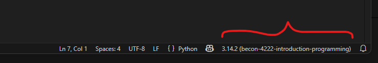

## Create a Python script

Create a first python script called `hello.py`, which contains the command `print('hello world')`. Run it from the script and run it with uv using the following command:

```bash
uv run hello.py
```

In the python file, right click and select “Run in Interactive Window”. You’ve run your first Python script of the course. 🎊

## Using the terminal be like

[figure not shown]

## Footnotes

[^1]: Note that `uv.lock` + `pyproject.toml` replace the traditional `requirements.txt` in `pip`. You can generate a requirements.txt file from uv using `uv pip freeze > requirements.txt`.